# Customer Segmentation Analysis - K-Means Clustering and RFM Analysis

## Project: Customer Segmentation and Analysis

### Stage Three: RFM (Recency, Frequency, Monetary) Analysis

### Introduction:

In this stage of the customer segmentation analysis, I delved into the dataset(cleaned) of the online retail store to unravel the intricacies of customer behaviour. By leveraging the powerful RFM (Recency, Frequency, Monetary) analysis and K-Means Clustering algorithm, I aimed to distill valuable insights that could profoundly impact business strategies and enhance customer-centric decision-making.

### Dataset Overview:

The dataset in this stage of the project encompasses a diverse array of almost 400K transactions, capturing the interactions of customers on the online retail platform. Features such as transaction dates(InvoiceDate), purchase amounts(UnitPrice), product quantity, stock code and customer identifiers form the foundation for a comprehensive exploration of customer dynamics.

### Objectives of the Analysis:

The primary Objectives of this analysis are as follows:

1. Segmentation for Potential Targeted Marketing:
   - How can customers be categorized into distinct segments based on thier recency, frequency, and monetary contributions?
   - What insights can these segments provide to guide marketing strategies for improved customer engagements?
2. Identifying High-Value Customers:
   - Can we identify or pinpoint high-value customers who contribute significantly to the business's revenue?
   - What patterns in recency, frequency, and monetary metrics characterize these high-value customers?
3. Understanding the correlation between RFM metrics:
   - How does recency and purchasing frequency affect monetary contributions of each customer segment?
4. Customizing Communication Strategies:
   - How can communication strategies be customized for different customer segments to enhance the overall customer experience
   - What personalized approaches can be adopted based on the identified RFM segments?

By delving into the recency, frequency and monetary dimensions of customer transactions, this analysis aims to provide actionable insights that empower the online retail store to optimize marketing efforts, improve customer engagement and experience.

|  | InvoiceNo | StockCode | Description | Quantity | InvoiceDate | UnitPrice | CustomerID | Country | TransactionType | TotalAmount | MonthWeek | MonthofYear |
| --- | --- | --- | --- | --- | --- | --- | --- | --- | --- | --- | --- | --- |
| 0 | 536365 | 85123 | WHITE HANGING HEART T-LIGHT HOLDER | 6 | 2010-12-01 08:26:00 | 2.55 | 17850 | United Kingdom | sale | 15.30 | W1 | Dec |
| 1 | 536365 | 71053 | WHITE METAL LANTERN | 6 | 2010-12-01 08:26:00 | 3.39 | 17850 | United Kingdom | sale | 20.34 | W1 | Dec |
| 2 | 536365 | 84406 | CREAM CUPID HEARTS COAT HANGER | 8 | 2010-12-01 08:26:00 | 2.75 | 17850 | United Kingdom | sale | 22.00 | W1 | Dec |
| 3 | 536365 | 84029 | KNITTED UNION FLAG HOT WATER BOTTLE | 6 | 2010-12-01 08:26:00 | 3.39 | 17850 | United Kingdom | sale | 20.34 | W1 | Dec |
| 4 | 536365 | 84029 | RED WOOLLY HOTTIE WHITE HEART. | 6 | 2010-12-01 08:26:00 | 3.39 | 17850 | United Kingdom | sale | 20.34 | W1 | Dec |

```
(399654, 12)
```

```
<class 'pandas.core.frame.DataFrame'>
RangeIndex: 399654 entries, 0 to 399653
Data columns (total 12 columns):
 #   Column           Non-Null Count   Dtype
---  ------           --------------   -----
 0   InvoiceNo        399654 non-null  int64
 1   StockCode        399654 non-null  int64
 2   Description      399654 non-null  object
 3   Quantity         399654 non-null  int64
 4   InvoiceDate      399654 non-null  object
 5   UnitPrice        399654 non-null  float64
 6   CustomerID       399654 non-null  int64
 7   Country          399654 non-null  object
 8   TransactionType  399654 non-null  object
 9   TotalAmount      399654 non-null  float64
 10  MonthWeek        399654 non-null  object
 11  MonthofYear      399654 non-null  object
dtypes: float64(2), int64(4), object(6)
memory usage: 36.6+ MB
```

### 1. Converting InvoiceDate from object to datetime datatype

```
InvoiceNo                   int64
StockCode                   int64
Description                object
Quantity                    int64
InvoiceDate        datetime64[ns]
UnitPrice                 float64
CustomerID                  int64
Country                    object
TransactionType            object
TotalAmount               float64
MonthWeek                  object
MonthofYear                object
dtype: object
```

### 2. Calculate RFM (Recency, Frequency, Monetary) Metrics

#### 2.1 Calculating Recency

```
Most recent date: 2011-12-09 12:50:00
```

```
CustomerID
12346   325 days 02:33:00
12347     1 days 20:58:00
12348    74 days 23:37:00
12349    18 days 02:59:00
12350   309 days 20:49:00
               ...
18280   277 days 02:58:00
18281   180 days 01:57:00
18282     7 days 01:07:00
18283     3 days 00:48:00
18287    42 days 03:21:00
Name: InvoiceDate, Length: 4363, dtype: timedelta64[ns]
```

#### 2.2 Calculating Frequency

```
CustomerID
12346     2
12347     7
12348     4
12349     1
12350     1
         ..
18280     1
18281     1
18282     3
18283    16
18287     3
Name: InvoiceNo, Length: 4363, dtype: int64
```

#### 2.3 Calculating Monetary

```
CustomerID
12346    154367.20
12347      4310.00
12348      1437.24
12349      1457.55
12350       294.40
           ...
18280       180.60
18281        80.82
18282       179.50
18283      2039.58
18287      1837.28
Name: TotalAmount, Length: 4363, dtype: float64
```

### 3. Create RFM Table

#### 3.1 Combine all RFM Metrics into a single table

| CustomerID | Recency | Frequency | Monetary |
| --- | --- | --- | --- |
| 12346 | 325 | 2 | 154367.20 |
| 12347 | 1 | 7 | 4310.00 |
| 12348 | 74 | 4 | 1437.24 |
| 12349 | 18 | 1 | 1457.55 |
| 12350 | 309 | 1 | 294.40 |
| ... | ... | ... | ... |
| 18280 | 277 | 1 | 180.60 |
| 18281 | 180 | 1 | 80.82 |
| 18282 | 7 | 3 | 179.50 |
| 18283 | 3 | 16 | 2039.58 |
| 18287 | 42 | 3 | 1837.28 |

4363 rows × 3 columns

```
(4363, 3)
```

The shape of the RFM table indicates that it has a total of **4363** rows and **3** columns

### 4. Performing K-Means Clustering on the dataset

The K-Means clustering method is an unsupervised machine learning technique or algorithm used to identify and group clusters of data objects in a dataset based on similarities.

#### 4.1 Standardize The Data

Standardizing the RFM values to ensure equal weight during clustering

#### 4.2 Choosing Number of Cluster(K)

#### 4.3 Plotting the Elbow Method

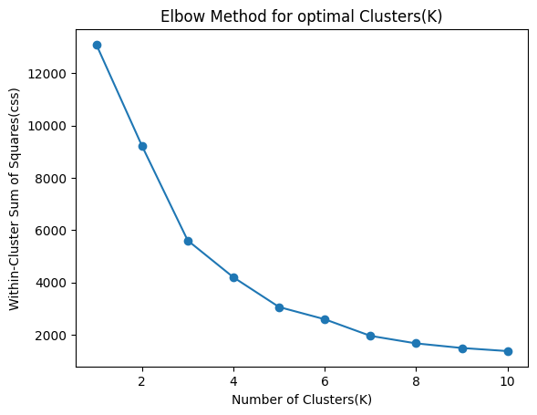

From the elbow method plot above, the number of clusters in our dataset will be 3.

#### 4.4 Applying K-Means Clustering

| CustomerID | Recency | Frequency | Monetary | Cluster |
| --- | --- | --- | --- | --- |
| 12346 | 325 | 2 | 154367.20 | 3 |
| 12347 | 1 | 7 | 4310.00 | 1 |
| 12348 | 74 | 4 | 1437.24 | 1 |
| 12349 | 18 | 1 | 1457.55 | 1 |
| 12350 | 309 | 1 | 294.40 | 2 |
| ... | ... | ... | ... | ... |
| 18280 | 277 | 1 | 180.60 | 2 |
| 18281 | 180 | 1 | 80.82 | 2 |
| 18282 | 7 | 3 | 179.50 | 1 |
| 18283 | 3 | 16 | 2039.58 | 1 |
| 18287 | 42 | 3 | 1837.28 | 1 |

4363 rows × 4 columns

#### 4.5 Grouping Each Clusters by the Means of Recency, Frequency and Monetary

```
            Recency  Frequency       Monetary
Cluster
1         38.784810    5.65761    2005.423939
2        245.192238    1.83213     577.414116
3         25.687500   89.56250  129591.279375
```

From the above means generated with respect to each cluster, we notice that:

1. In terms of **'Recency'**, `Cluster 3` had the least value which meant customers from that cluster performed a transaction or visited the site most recently. This is followed by `Cluster 1` with the next least recency value. `Cluster 2` recorded the highest recency value, meaning it has been a long time since customers of that cluster performed any transaction on or visited the online platform.
2. In terms of how **'Frequent'** customers in each cluster transacted on the platform, `Cluster 3` recorded the highest frequency of the three clusters, followed by customers in `Cluster 1`, with customers belonging to `Cluster 2` recording the least or lowest mean frequency of the three cluster groups.
3. For **'Monetary'**, the same observation can be made. `Cluster 3` recorded the highest mean monetary value among the three clusters. This is followed by `Cluster 1`, with `Cluster 2` recording the lowest mean monetary value of the three cluster groups.

```
Cluster  Recency  Frequency  Monetary
1        0        1          227.39       1
         91       2          547.90       1
                  6          765.70       1
                  4          1007.03      1
                  3          1255.00      1
                                         ..
3        7        49         199206.05    1
         9        64         119434.39    1
         23       24         125490.88    1
         38       66         85046.25     1
         325      2          154367.20    1
Name: count, Length: 4363, dtype: int64
```

#### 4.6 Implementing Customer Categorization Rules Based on Cluster Means

For this, three levels of categorization will be used to represent the three customer clusters identified.

1. High-Value: These customers exhibit the best RFM values and are the most valuable to the business. Criteria include;
   - Lower recency
   - High frequency
   - High monetary
2. Average: This group of customers have moderate RFM values. Criteria for this category include:
   - Moderate recency (not the most recent but not too old)
   - Moderate frequency (average number of transactions)
   - Moderate monetary value (average spending)
3. Low-Value: This last group of customers have the least attractive RFM values. Criteria include;
   - High recency (haven't made a purchase or transacted in a long time)
   - Lowest frequency
   - Lowest monetary value

| CustomerID | Recency | Frequency | Monetary | Cluster | CustomerCategory |
| --- | --- | --- | --- | --- | --- |
| 12346 | 325 | 2 | 154367.20 | 3 | High Value |
| 12347 | 1 | 7 | 4310.00 | 1 | Average |
| 12348 | 74 | 4 | 1437.24 | 1 | Average |
| 12349 | 18 | 1 | 1457.55 | 1 | Average |
| 12350 | 309 | 1 | 294.40 | 2 | Low Value |
| ... | ... | ... | ... | ... | ... |
| 18280 | 277 | 1 | 180.60 | 2 | Low Value |
| 18281 | 180 | 1 | 80.82 | 2 | Low Value |
| 18282 | 7 | 3 | 179.50 | 1 | Average |
| 18283 | 3 | 16 | 2039.58 | 1 | Average |
| 18287 | 42 | 3 | 1837.28 | 1 | Average |

4363 rows × 5 columns

```
CustomerCategory
Average       3239
Low Value     1108
High Value      16
Name: count, dtype: int64
```

From the above output;

- Average value customers have the most representation among the three clusters with a total of **3239**. This is followed by low value category of customers with **1108** and then high value customers with just **16**.

### 5. Visualization of Customer Segments using RFM Values

Bar charts, scatter plots, pie charts and a few other charts will be used to visualize relationship between the RFM values, and the data as a whole. We will be using both the clean data `online_retail_cl.csv` stored in the `df` variable and the `rfm_table` containing our RFM values and customer categorization.

#### 5.1 Plot for the distribution of Customer Segments

[interactive chart not shown]

#### 5.1.1 Customer Segment Distribution by Proportion (%)

[interactive chart not shown]

#### 5.2 Plotting Monetary values realized from each customer segment

[interactive chart not shown]

#### 5.3 Plotting Recency values for each customer segment

```
CustomerCategory
High Value       411
Average       125624
Low Value     271673
Name: Recency, dtype: int64
```

[interactive chart not shown]

#### 5.4 Plotting the Frequency of each customer segment

```
CustomerCategory
High Value     1433
Low Value      2030
Average       18325
Name: Frequency, dtype: int64
```

[interactive chart not shown]

#### 5.5 Plot to visualize Relationship between RFM Metrics / Values

For this task a scatter plot will be used to visualize the relationship between the two RFm values. This will help identify patterns across the different customer segments with respect to these two values.

#### 5.5.1 Plot to visualize Relationship between Frequency and Monetary values

[interactive chart not shown]

From the scatter plot above, the following observations were made with respect to the relationship between `Frequency` which is the number of times a customer visited the online retail store and performed a transaction and `Monetary` which represents the total monetary value of each customer's trasanction.

We can conclude from the representation of data points on the scatter plot with respect to the three customer segment, that:

- A higher frequency (Number of visits) does not translate into a corresponding higher monetary value and vice versa.

#### 5.5.2 Plot to visualize Relationship between Recency and Monetary values

[interactive chart not shown]

#### Insight:

From the above scatter plot above, the following observation was made of the relationship between `Recency` which represents how current or recent a customer's visit to the online retail store is and the `Monetary` value realized from their visit.

| CustomerID | Recency | Frequency | Monetary | Cluster | CustomerCategory |
| --- | --- | --- | --- | --- | --- |
| 16446 | 0 | 3 | 336942.10 | 3 | High Value |
| 18102 | 0 | 60 | 259657.30 | 3 | High Value |
| 14911 | 0 | 242 | 143555.42 | 3 | High Value |
| 15311 | 0 | 118 | 61981.31 | 3 | High Value |
| 12748 | 0 | 217 | 33481.57 | 3 | High Value |
| 14606 | 0 | 125 | 12365.70 | 3 | High Value |

From the above table, we see that customer with ID **16446** recorded the least frequency value of **3** but also recorded the highest monetary value of **336,942K**.

2. Majority of the customers of the online retail store fall in the `Average` customer segment. This segment recorded a recency value ranging from **0** to **162**.

| CustomerID | Recency | Frequency | Monetary | Cluster | CustomerCategory |
| --- | --- | --- | --- | --- | --- |
| 16684 | 3 | 30 | 67387.00 | 1 | Average |
| 17949 | 0 | 49 | 62845.22 | 1 | Average |
| 15769 | 6 | 29 | 60681.72 | 1 | Average |
| 15061 | 3 | 54 | 54817.94 | 1 | Average |
| 14096 | 3 | 17 | 53258.43 | 1 | Average |
| ... | ... | ... | ... | ... | ... |
| 13307 | 119 | 1 | 15.00 | 1 | Average |
| 14792 | 63 | 2 | 12.40 | 1 | Average |
| 16454 | 63 | 1 | 5.90 | 1 | Average |
| 16428 | 80 | 1 | 2.95 | 1 | Average |
| 13256 | 13 | 1 | 0.00 | 1 | Average |

3239 rows × 5 columns

#### Insight:

From the table above, the highest monetary value realized from this segment is **67,387.00K** with a recency value of **3**, meaning customer with ID **16684** visited the online store very recently and during this time this customer visited the store **30** times. We can also see that customer with ID **13256** last visit to the online store was 13 days ago from our data and visited the site only once and performed no transaction of any kind accounting for a monetary value of **0.00**.

3. `Low Value` customers account for the second highest number of customers in our data. Customers within this segment recorded a recency value of between **135** to **373**. In terms of monetary value, a high of **67,532.70K** was realized to as low as **1.25**.

| CustomerID | Recency | Frequency | Monetary | Cluster | CustomerCategory |
| --- | --- | --- | --- | --- | --- |
| 15749 | 234 | 4 | 67532.70 | 2 | Low Value |
| 15098 | 181 | 4 | 40213.50 | 2 | Low Value |
| 12590 | 189 | 2 | 9344.14 | 2 | Low Value |
| 13093 | 266 | 13 | 7923.47 | 2 | Low Value |
| 17850 | 301 | 35 | 5478.94 | 2 | Low Value |
| ... | ... | ... | ... | ... | ... |
| 12605 | 364 | 1 | 7.50 | 2 | Low Value |
| 16738 | 297 | 1 | 3.75 | 2 | Low Value |
| 12943 | 300 | 1 | 3.75 | 2 | Low Value |
| 14679 | 371 | 1 | 2.55 | 2 | Low Value |
| 16995 | 371 | 1 | 1.25 | 2 | Low Value |

1108 rows × 5 columns

#### Insight:

The table above shows customer with ID **15749** visited the online store **234** days ago since his or her last visit and in that time visited the store only **4** times but still recorded the highest monetary value of **67,532.70** in this segment.